```python
# Import Required Libraries

import pandas as pd
import numpy as np
import matplotlib.pyplot as plt
import scipy.stats as stats
import openpyxl

# Display all columns
pd.set_option("display.max_columns", None)

print("All libraries imported successfully!")
```

```
All libraries imported successfully!
```

# Exploratory Data Analysis (EDA)

## Project 2

**Student:** Muhammad Afzaal

**Tools Used:**

- Python
- Pandas
- NumPy
- Matplotlib
- SciPy
- OpenPyXL
- Jupyter Notebook

```python
# Load Dataset

file_path = "../Data/Dataset.xlsx"

df = pd.read_excel(file_path)

print("Dataset loaded successfully!")
```

```
Dataset loaded successfully!
```

# Dataset Overview

In this section, we will inspect the dataset to understand its structure, dimensions, column names, data types, and overall quality before performing any analysis.

```python
# Dataset Shape

print("Rows and Columns:")
print(df.shape)
```

```
Rows and Columns:
(1200, 14)
```

```python
# First Five Rows

df.head()
```

|  | OrderID | Date | CustomerID | Product | Quantity | UnitPrice | ShippingAddress | PaymentMethod | OrderStatus | TrackingNumber | ItemsInCart | CouponCode | ReferralSource | TotalPrice |
| --- | --- | --- | --- | --- | --- | --- | --- | --- | --- | --- | --- | --- | --- | --- |
| 0 | ORD200000 | 2023-01-04 | C72649 | Monitor | 5 | 570.62 | 928 Main St | Debit Card | Shipped | TRK37947903 | 7 | SAVE10 | Instagram | 2853.10 |
| 1 | ORD200001 | 2024-08-23 | C75739 | Phone | 2 | 151.35 | 823 Main St | Online | Shipped | TRK91186779 | 3 | SAVE10 | Referral | 302.70 |
| 2 | ORD200002 | 2024-02-27 | C81728 | Tablet | 5 | 550.68 | 512 Main St | Credit Card | Cancelled | TRK42903982 | 8 | FREESHIP | Email | 2753.40 |
| 3 | ORD200003 | 2023-10-15 | C33540 | Chair | 1 | 273.19 | 275 Main St | Debit Card | Returned | TRK62788070 | 5 | SAVE10 | Facebook | 273.19 |
| 4 | ORD200004 | 2025-05-08 | C81840 | Printer | 4 | 626.01 | 668 Main St | Online | Delivered | TRK29241424 | 8 | SAVE10 | Email | 2504.04 |

```python
# Last Five Rows

df.tail()
```

|  | OrderID | Date | CustomerID | Product | Quantity | UnitPrice | ShippingAddress | PaymentMethod | OrderStatus | TrackingNumber | ItemsInCart | CouponCode | ReferralSource | TotalPrice |
| --- | --- | --- | --- | --- | --- | --- | --- | --- | --- | --- | --- | --- | --- | --- |
| 1195 | ORD201195 | 2024-06-20 | C21126 | Desk | 1 | 107.04 | 392 Main St | Credit Card | Cancelled | TRK38009181 | 6 | FREESHIP | Google | 107.04 |
| 1196 | ORD201196 | 2024-03-04 | C20095 | Monitor | 2 | 662.53 | 778 Main St | Online | Cancelled | TRK69207593 | 5 | NaN | Facebook | 1325.06 |
| 1197 | ORD201197 | 2023-07-13 | C79674 | Tablet | 2 | 436.84 | 275 Main St | Online | Delivered | TRK88039356 | 2 | FREESHIP | Instagram | 873.68 |
| 1198 | ORD201198 | 2024-08-22 | C64753 | Chair | 4 | 262.52 | 509 Main St | Debit Card | Cancelled | TRK71683331 | 4 | WINTER15 | Instagram | 1050.08 |
| 1199 | ORD201199 | 2023-06-11 | C57502 | Tablet | 4 | 560.58 | 201 Main St | Gift Card | Returned | TRK51116746 | 6 | SAVE10 | Referral | 2242.32 |

```python
# Column Names

print(df.columns)
```

```
Index(['OrderID', 'Date', 'CustomerID', 'Product', 'Quantity', 'UnitPrice',
       'ShippingAddress', 'PaymentMethod', 'OrderStatus', 'TrackingNumber',
       'ItemsInCart', 'CouponCode', 'ReferralSource', 'TotalPrice'],
      dtype='str')
```

```python
# Dataset Information

df.info()
```

```
<class 'pandas.DataFrame'>
RangeIndex: 1200 entries, 0 to 1199
Data columns (total 14 columns):
 #   Column           Non-Null Count  Dtype
---  ------           --------------  -----
 0   OrderID          1200 non-null   str
 1   Date             1200 non-null   datetime64[us]
 2   CustomerID       1200 non-null   str
 3   Product          1200 non-null   str
 4   Quantity         1200 non-null   int64
 5   UnitPrice        1200 non-null   float64
 6   ShippingAddress  1200 non-null   str
 7   PaymentMethod    1200 non-null   str
 8   OrderStatus      1200 non-null   str
 9   TrackingNumber   1200 non-null   str
 10  ItemsInCart      1200 non-null   int64
 11  CouponCode       891 non-null    str
 12  ReferralSource   1200 non-null   str
 13  TotalPrice       1200 non-null   float64
dtypes: datetime64[us](1), float64(2), int64(2), str(9)
memory usage: 131.4 KB
```

```python
# Descriptive Statistics

df.describe()
```

|  | Date | Quantity | UnitPrice | ItemsInCart | TotalPrice |
| --- | --- | --- | --- | --- | --- |
| count | 1200 | 1200.000000 | 1200.000000 | 1200.000000 | 1200.000000 |
| mean | 2024-03-22 16:58:48 | 2.945833 | 356.412750 | 5.485000 | 1053.968300 |
| min | 2023-01-01 00:00:00 | 1.000000 | 11.390000 | 1.000000 | 11.390000 |
| 25% | 2023-08-03 18:00:00 | 2.000000 | 186.062500 | 4.000000 | 410.520000 |
| 50% | 2024-03-23 00:00:00 | 3.000000 | 364.210000 | 5.000000 | 823.615000 |
| 75% | 2024-11-08 12:00:00 | 4.000000 | 521.570000 | 7.000000 | 1578.475000 |
| max | 2025-06-30 00:00:00 | 5.000000 | 699.930000 | 10.000000 | 3456.400000 |
| std | NaN | 1.407557 | 197.177146 | 2.281983 | 819.856558 |

```python
# Missing Values

missing_values = df.isnull().sum()

print(missing_values)
```

```
OrderID              0
Date                 0
CustomerID           0
Product              0
Quantity             0
UnitPrice            0
ShippingAddress      0
PaymentMethod        0
OrderStatus          0
TrackingNumber       0
ItemsInCart          0
CouponCode         309
ReferralSource       0
TotalPrice           0
dtype: int64
```

```python
# Duplicate Records

print("Duplicate Rows:", df.duplicated().sum())
```

```
Duplicate Rows: 0
```

```python
# Data Types

print(df.dtypes)
```

```
OrderID                       str
Date               datetime64[us]
CustomerID                    str
Product                       str
Quantity                    int64
UnitPrice                 float64
ShippingAddress               str
PaymentMethod                 str
OrderStatus                   str
TrackingNumber                str
ItemsInCart                 int64
CouponCode                    str
ReferralSource                str
TotalPrice                float64
dtype: object
```

# Data Cleaning

In this section, we will clean the dataset by handling missing values, verifying data types, checking data consistency, and preparing the data for analysis.

```python
# Data Types

df.dtypes
```

```
OrderID                       str
Date               datetime64[us]
CustomerID                    str
Product                       str
Quantity                    int64
UnitPrice                 float64
ShippingAddress               str
PaymentMethod                 str
OrderStatus                   str
TrackingNumber                str
ItemsInCart                 int64
CouponCode                    str
ReferralSource                str
TotalPrice                float64
dtype: object
```

```python
# Convert Date Column

df["Date"] = pd.to_datetime(df["Date"])

print("Date column converted successfully!")
```

```
Date column converted successfully!
```

```python
# Handle Missing Coupon Codes

df["CouponCode"] = df["CouponCode"].fillna("No Coupon")

print("Missing Coupon Codes handled successfully!")
```

```
Missing Coupon Codes handled successfully!
```

```python
# Verify Missing Values

df.isnull().sum()
```

```
OrderID            0
Date               0
CustomerID         0
Product            0
Quantity           0
UnitPrice          0
ShippingAddress    0
PaymentMethod      0
OrderStatus        0
TrackingNumber     0
ItemsInCart        0
CouponCode         0
ReferralSource     0
TotalPrice         0
dtype: int64
```

```python
# Feature Engineering

df["Year"] = df["Date"].dt.year
df["Month"] = df["Date"].dt.month_name()
df["MonthNumber"] = df["Date"].dt.month
df["Quarter"] = df["Date"].dt.quarter
df["Day"] = df["Date"].dt.day_name()

print("New features created successfully!")
```

```
New features created successfully!
```

```python
df.head()
```

|  | OrderID | Date | CustomerID | Product | Quantity | UnitPrice | ShippingAddress | PaymentMethod | OrderStatus | TrackingNumber | ItemsInCart | CouponCode | ReferralSource | TotalPrice | Year | Month | MonthNumber | Quarter | Day |
| --- | --- | --- | --- | --- | --- | --- | --- | --- | --- | --- | --- | --- | --- | --- | --- | --- | --- | --- | --- |
| 0 | ORD200000 | 2023-01-04 | C72649 | Monitor | 5 | 570.62 | 928 Main St | Debit Card | Shipped | TRK37947903 | 7 | SAVE10 | Instagram | 2853.10 | 2023 | January | 1 | 1 | Wednesday |
| 1 | ORD200001 | 2024-08-23 | C75739 | Phone | 2 | 151.35 | 823 Main St | Online | Shipped | TRK91186779 | 3 | SAVE10 | Referral | 302.70 | 2024 | August | 8 | 3 | Friday |
| 2 | ORD200002 | 2024-02-27 | C81728 | Tablet | 5 | 550.68 | 512 Main St | Credit Card | Cancelled | TRK42903982 | 8 | FREESHIP | Email | 2753.40 | 2024 | February | 2 | 1 | Tuesday |
| 3 | ORD200003 | 2023-10-15 | C33540 | Chair | 1 | 273.19 | 275 Main St | Debit Card | Returned | TRK62788070 | 5 | SAVE10 | Facebook | 273.19 | 2023 | October | 10 | 4 | Sunday |
| 4 | ORD200004 | 2025-05-08 | C81840 | Printer | 4 | 626.01 | 668 Main St | Online | Delivered | TRK29241424 | 8 | SAVE10 | Email | 2504.04 | 2025 | May | 5 | 2 | Thursday |

## Analysis 1: Monthly Orders

This analysis examines the number of customer orders placed each month. It helps identify seasonal trends, peak business periods, and fluctuations in customer purchasing behavior.

### Objective

- Determine the total number of orders placed each month.
- Identify months with the highest and lowest order volumes.
- Understand monthly ordering trends.

### Visualization

A bar chart is used to compare the number of orders across different months.

### Interpretation

The bar chart displays the monthly distribution of customer orders. Higher bars indicate months with increased customer activity, while lower bars indicate periods with fewer orders.

### Key Insight

This analysis helps identify seasonal demand patterns and supports better inventory management, staffing, and marketing strategies.

```python
# Monthly Orders

monthly_orders = df.groupby("Month")["OrderID"].count()

monthly_orders = monthly_orders.reindex([
    "January","February","March","April","May","June",
    "July","August","September","October","November","December"
])

print(monthly_orders)
```

```
Month
January      106
February     106
March        128
April        113
May          120
June         147
July          87
August        79
September     73
October       78
November      76
December      87
Name: OrderID, dtype: int64
```

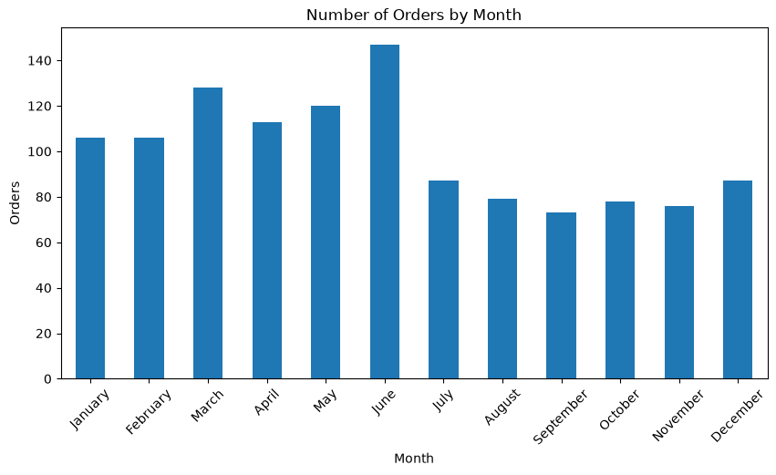

```python
plt.figure(figsize=(10,5))

monthly_orders.plot(kind="bar")

plt.title("Number of Orders by Month")
plt.xlabel("Month")
plt.ylabel("Orders")
plt.xticks(rotation=45)

plt.savefig("../Charts/monthly_orders.png", dpi=300, bbox_inches="tight")

plt.show()
```

## Analysis 2: Monthly Revenue

This analysis evaluates the total revenue generated each month to understand sales performance and revenue trends over time.

### Objective

- Calculate total monthly revenue.
- Identify the highest and lowest revenue months.
- Analyze revenue growth or decline.

### Visualization

A line chart is used to illustrate monthly revenue trends.

### Interpretation

The line chart shows how revenue changes throughout the year. Peaks represent months with strong sales performance, while declines indicate weaker business periods.

### Key Insight

Understanding monthly revenue trends helps businesses improve forecasting, budgeting, and sales planning.

```python
monthly_revenue = df.groupby("Month")["TotalPrice"].sum()

monthly_revenue = monthly_revenue.reindex([
    "January","February","March","April","May","June",
    "July","August","September","October","November","December"
])

monthly_revenue
```

```
Month
January      124313.23
February     112344.78
March        123840.93
April        109186.05
May          135142.59
June         170616.13
July          85784.64
August        86343.21
September     69321.65
October       89834.82
November      75493.43
December      82540.50
Name: TotalPrice, dtype: float64
```

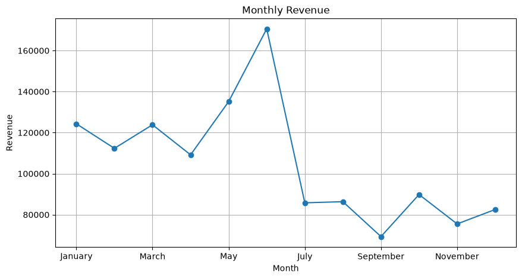

```python
plt.figure(figsize=(10,5))

monthly_revenue.plot(kind="line", marker="o")

plt.title("Monthly Revenue")
plt.xlabel("Month")
plt.ylabel("Revenue")
plt.grid(True)

plt.savefig("../Charts/monthly_revenue.png", dpi=300, bbox_inches="tight")

plt.show()
```

This analysis identifies the products with the highest sales quantity.

### Objective

- Determine the best-selling products.
- Compare product demand.
- Support inventory and product planning.

### Interpretation

The chart ranks products according to the total quantity sold. Products with the highest bars are the most popular among customers.

### Key Insight

Best-selling products contribute significantly to overall sales and should be prioritized for inventory management and promotional activities.

```python
top_products = (
    df.groupby("Product")["Quantity"]
      .sum()
      .sort_values(ascending=False)
      .head(10)
)

top_products
```

```
Product
Chair      562
Printer    542
Laptop     535
Desk       508
Tablet     497
Monitor    480
Phone      411
Name: Quantity, dtype: int64
```

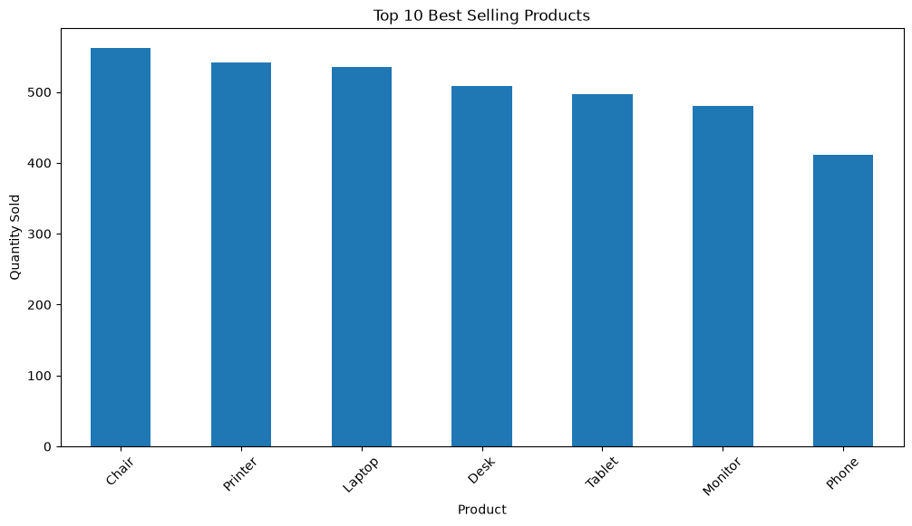

```python
plt.figure(figsize=(12,6))

top_products.plot(kind="bar")

plt.title("Top 10 Best Selling Products")
plt.xlabel("Product")
plt.ylabel("Quantity Sold")
plt.xticks(rotation=45)

plt.savefig("../Charts/top_10_best_selling_products.png", dpi=300, bbox_inches="tight")

plt.show()
```

## Analysis 4: Payment Method Distribution

This analysis explores the payment methods preferred by customers during purchases.

### Objective

- Identify the most commonly used payment methods.
- Compare customer payment preferences.
- Understand payment behavior.

### Visualization

A pie chart is used to display the percentage distribution of each payment method.

### Interpretation

The pie chart illustrates the share of each payment method used by customers. Larger segments indicate more popular payment options.

### Key Insight

Knowing customer payment preferences helps businesses optimize payment services and improve the checkout experience.

```python
payment = df["PaymentMethod"].value_counts()

payment
```

```
PaymentMethod
Online         258
Cash           246
Credit Card    234
Debit Card     232
Gift Card      230
Name: count, dtype: int64
```

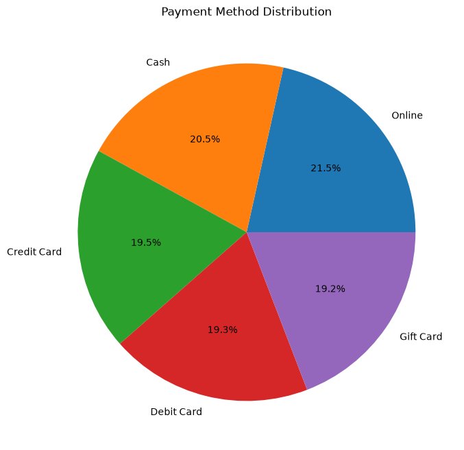

```python
plt.figure(figsize=(8,8))

payment.plot(kind="pie", autopct="%1.1f%%")

plt.ylabel("")
plt.title("Payment Method Distribution")

plt.savefig("../Charts/payment_method_distribution.png", dpi=300, bbox_inches="tight")

plt.show()
```

## Analysis 5: Order Status Distribution

This analysis examines the distribution of different order statuses.

### Objective

- Determine the number of delivered, pending, and cancelled orders.
- Evaluate order fulfillment performance.
- Identify operational trends.

### Visualization

A bar chart is used to compare the frequency of each order status.

### Interpretation

The chart shows the number of orders in each status category. A higher number of delivered orders indicates successful order processing.

### Key Insight

Monitoring order status helps businesses improve operational efficiency and customer satisfaction.

```python
status = df["OrderStatus"].value_counts()

status
```

```
OrderStatus
Cancelled    250
Returned     247
Pending      237
Shipped      235
Delivered    231
Name: count, dtype: int64
```

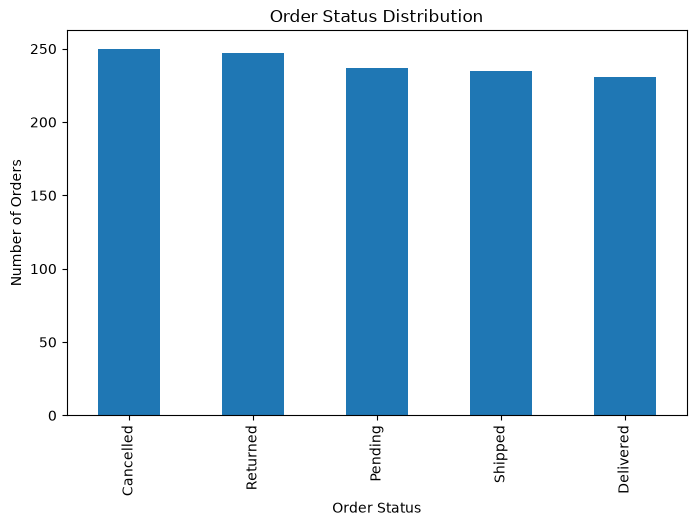

```python
plt.figure(figsize=(8,5))

status.plot(kind="bar")

plt.title("Order Status Distribution")
plt.xlabel("Order Status")
plt.ylabel("Number of Orders")

plt.savefig("../Charts/order_status_distribution.png", dpi=300, bbox_inches="tight")

plt.show()
```

## Analysis 6: Referral Source Analysis

This analysis investigates the sources through which customers reached the online store.

### Objective

- Identify the most effective referral channels.
- Compare customer acquisition sources.
- Evaluate marketing performance.

### Visualization

A bar chart is used to compare referral sources.

### Interpretation

The chart highlights which referral sources contribute the highest number of customers.

### Key Insight

The most successful referral channels should receive greater marketing investment to maximize customer acquisition.

```python
referral = df["ReferralSource"].value_counts()

referral
```

```
ReferralSource
Instagram    259
Email        250
Google       241
Facebook     228
Referral     222
Name: count, dtype: int64
```

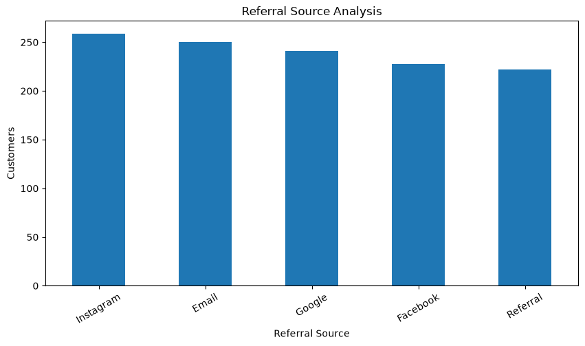

```python
plt.figure(figsize=(10,5))

referral.plot(kind="bar")

plt.title("Referral Source Analysis")
plt.xlabel("Referral Source")
plt.ylabel("Customers")
plt.xticks(rotation=30)

plt.savefig("../Charts/referral_source_analysis.png", dpi=300, bbox_inches="tight")

plt.show()
```

## Analysis 7: Coupon Usage Analysis

This analysis evaluates the usage of promotional coupon codes by customers.

### Objective

- Identify the most frequently used coupon codes.
- Compare coupon usage.
- Measure customer response to promotions.

### Visualization

A bar chart is used to display the most frequently used coupon codes.

### Interpretation

The chart presents the popularity of different coupon codes. Frequently used coupons indicate successful promotional campaigns.

### Key Insight

Coupon analysis helps businesses evaluate the effectiveness of marketing promotions and customer engagement strategies.

```python
coupon = df["CouponCode"].value_counts()

coupon.head(10)
```

```
CouponCode
FREESHIP     313
No Coupon    309
WINTER15     292
SAVE10       286
Name: count, dtype: int64
```

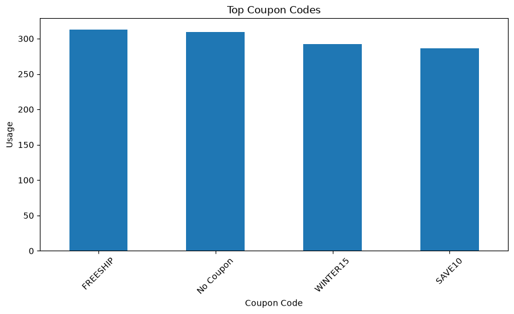

```python
plt.figure(figsize=(10,5))

coupon.head(10).plot(kind="bar")

plt.title("Top Coupon Codes")
plt.xlabel("Coupon Code")
plt.ylabel("Usage")
plt.xticks(rotation=45)

plt.savefig("../Charts/coupon_usage_analysis.png", dpi=300, bbox_inches="tight")

plt.show()
```

## Analysis 8: Quantity Distribution

This analysis examines the distribution of product quantities ordered by customers.

### Objective

- Understand purchasing patterns.
- Identify the most common order quantities.
- Detect unusual purchasing behavior.

### Visualization

A histogram is used to display the frequency distribution of ordered quantities.

### Interpretation

The histogram shows how frequently different quantities occur in customer orders.

### Key Insight

Understanding quantity distribution supports inventory planning and demand forecasting.

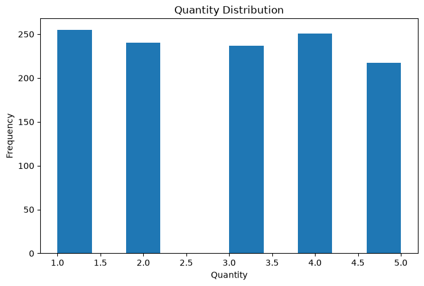

```python
plt.figure(figsize=(8,5))

plt.hist(df["Quantity"], bins=10)

plt.title("Quantity Distribution")
plt.xlabel("Quantity")
plt.ylabel("Frequency")

plt.savefig("../Charts/quantity_distribution.png", dpi=300, bbox_inches="tight")

plt.show()
```

## Analysis 9: Total Price Distribution

This analysis explores the distribution of total order values.

### Objective

- Understand customer spending patterns.
- Identify common purchase values.
- Detect unusually high-value orders.

### Visualization

A histogram is used to display the distribution of total order prices.

### Interpretation

The histogram illustrates how customer spending is distributed across all orders.

### Key Insight

Analyzing spending patterns helps businesses understand customer purchasing behavior and pricing strategies.

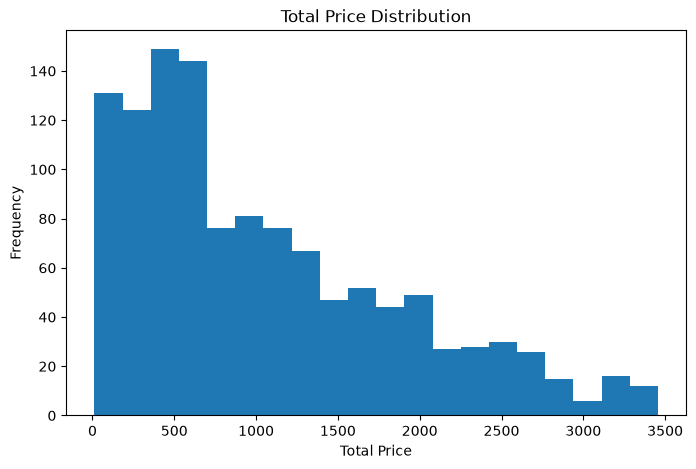

```python
plt.figure(figsize=(8,5))

plt.hist(df["TotalPrice"], bins=20)

plt.title("Total Price Distribution")
plt.xlabel("Total Price")
plt.ylabel("Frequency")

plt.savefig("../Charts/total_price_distribution.png", dpi=300, bbox_inches="tight")

plt.show()
```

## Analysis 10: Unit Price vs Total Price

This analysis investigates the relationship between unit price and total order price.

### Objective

- Examine the relationship between product price and total purchase value.
- Identify trends in customer spending.
- Detect unusual observations.

### Visualization

A scatter plot is used to visualize the relationship between unit price and total price.

### Interpretation

Each point represents an order. A positive relationship indicates that higher-priced products generally contribute to higher total order values.

### Key Insight

Understanding this relationship assists businesses in pricing decisions and sales performance analysis.

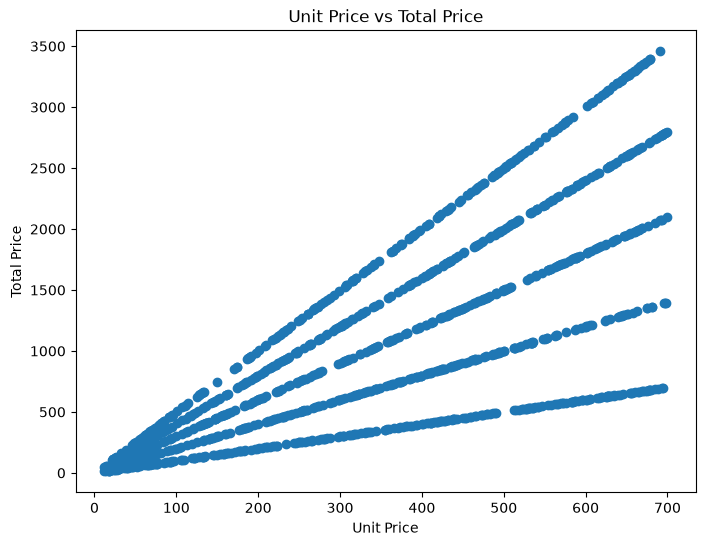

```python
plt.figure(figsize=(8,6))

plt.scatter(df["UnitPrice"], df["TotalPrice"])

plt.title("Unit Price vs Total Price")
plt.xlabel("Unit Price")
plt.ylabel("Total Price")

plt.savefig("../Charts/unitprice_vs_totalprice.png", dpi=300, bbox_inches="tight")

plt.show()
```

## Analysis 11: Correlation Analysis

This analysis measures the relationship between numerical variables in the dataset.

### Objective

- Identify relationships among numerical variables.
- Detect positive and negative correlations.
- Support data-driven decision making.

### Visualization

A correlation heatmap is used to visualize relationships between numerical features.

### Interpretation

The heatmap displays correlation coefficients ranging from -1 to +1. Values closer to +1 indicate strong positive relationships, while values closer to -1 indicate strong negative relationships.

### Key Insight

Correlation analysis helps identify factors that influence sales performance and customer purchasing behavior.

```python
numeric_df = df.select_dtypes(include=np.number)

numeric_df.corr()
```

|  | Quantity | UnitPrice | ItemsInCart | TotalPrice | Year | MonthNumber | Quarter |
| --- | --- | --- | --- | --- | --- | --- | --- |
| Quantity | 1.000000 | 0.014553 | 0.650061 | 0.615251 | -0.033229 | -0.015118 | -0.013799 |
| UnitPrice | 0.014553 | 1.000000 | 0.000602 | 0.717081 | -0.002233 | -0.026130 | -0.026416 |
| ItemsInCart | 0.650061 | 0.000602 | 1.000000 | 0.392540 | -0.050464 | -0.018151 | -0.018386 |
| TotalPrice | 0.615251 | 0.717081 | 0.392540 | 1.000000 | -0.036174 | -0.027734 | -0.023235 |
| Year | -0.033229 | -0.002233 | -0.050464 | -0.036174 | 1.000000 | -0.269465 | -0.295158 |
| MonthNumber | -0.015118 | -0.026130 | -0.018151 | -0.027734 | -0.269465 | 1.000000 | 0.969097 |
| Quarter | -0.013799 | -0.026416 | -0.018386 | -0.023235 | -0.295158 | 0.969097 | 1.000000 |

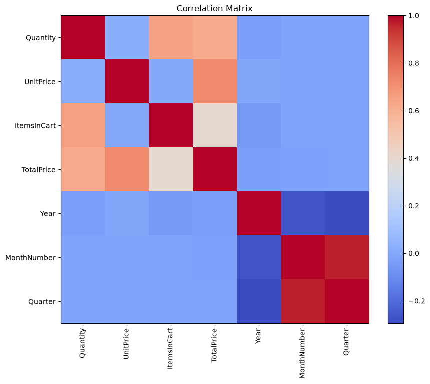

```python
plt.figure(figsize=(10,8))

plt.imshow(numeric_df.corr(), cmap="coolwarm")

plt.colorbar()

plt.xticks(
    range(len(numeric_df.columns)),
    numeric_df.columns,
    rotation=90
)

plt.yticks(
    range(len(numeric_df.columns)),
    numeric_df.columns
)

plt.title("Correlation Matrix")

plt.savefig("../Charts/correlation_heatmap.png", dpi=300, bbox_inches="tight")

plt.show()
```

## Analysis 12: Outlier Detection

This analysis identifies unusually high or low values within the numerical data.

### Visualization

Boxplots are used to identify outliers in numerical variables.

### Interpretation

Values outside the whiskers represent potential outliers. These observations may require further investigation.

### Key Insight

Outlier detection improves the reliability of statistical analysis and helps identify exceptional business events or data entry issues.

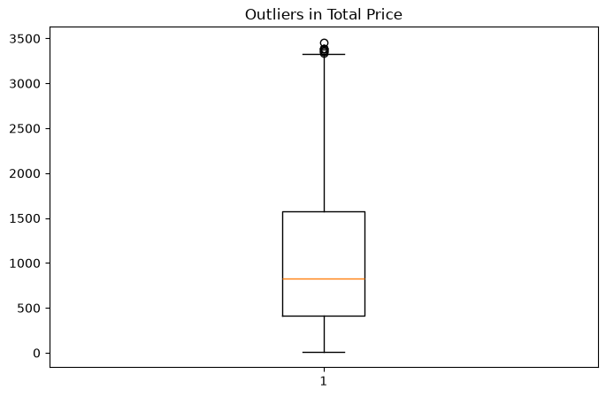

```python
plt.figure(figsize=(8,5))

plt.boxplot(df["TotalPrice"])

plt.title("Outliers in Total Price")
plt.savefig("../Charts/outliers_totalprice.png", dpi=300, bbox_inches="tight")

plt.show()
```

# Statistical Analysis

This section performs statistical analysis on the numerical variables to better understand the central tendency, variability, and relationships within the dataset.

```python
# Summary Statistics

numerical_columns = ["Quantity", "UnitPrice", "TotalPrice"]

df[numerical_columns].describe().T
```

|  | count | mean | std | min | 25% | 50% | 75% | max |
| --- | --- | --- | --- | --- | --- | --- | --- | --- |
| Quantity | 1200.0 | 2.945833 | 1.407557 | 1.00 | 2.0000 | 3.000 | 4.000 | 5.00 |
| UnitPrice | 1200.0 | 356.412750 | 197.177146 | 11.39 | 186.0625 | 364.210 | 521.570 | 699.93 |
| TotalPrice | 1200.0 | 1053.968300 | 819.856558 | 11.39 | 410.5200 | 823.615 | 1578.475 | 3456.40 |

```python
# Skewness

print("Skewness:\n")
print(df[numerical_columns].skew())
```

```
Skewness:

Quantity      0.027922
UnitPrice    -0.026512
TotalPrice    0.891359
dtype: float64
```

```python
# Kurtosis

print("Kurtosis:\n")
print(df[numerical_columns].kurt())
```

```
Kurtosis:

Quantity     -1.294596
UnitPrice    -1.191011
TotalPrice   -0.040415
dtype: float64
```

```python
# Correlation Matrix

corr = df[numerical_columns].corr()

corr
```

|  | Quantity | UnitPrice | TotalPrice |
| --- | --- | --- | --- |
| Quantity | 1.000000 | 0.014553 | 0.615251 |
| UnitPrice | 0.014553 | 1.000000 | 0.717081 |
| TotalPrice | 0.615251 | 0.717081 | 1.000000 |

# Business Insights

# Conclusion

The exploratory data analysis provided valuable insights into customer purchasing behavior, sales trends, payment preferences, and product performance.

The dataset was successfully cleaned, transformed, and analyzed using Python and various data analysis libraries. Visualizations revealed important trends that can support business decision-making.

Overall, the analysis demonstrates how data-driven approaches can improve operational efficiency, customer satisfaction, and strategic planning.

# Recommendations

Based on the findings, the following recommendations are suggested:

1. Increase inventory for best-selling products.
2. Launch promotional campaigns during low-sales months.
3. Focus marketing efforts on the highest-performing referral channels.
4. Improve customer engagement through personalized coupon campaigns.
5. Monitor cancelled orders to reduce order failure rates.
6. Analyze high-value customers separately for loyalty programs.
7. Continue monitoring sales trends for better demand forecasting.
8. Regularly perform exploratory data analysis to support business decision-making.

# Export Clean Dataset

The cleaned dataset is saved for future analysis and machine learning tasks.

```python
# Save Clean Dataset


df.to_excel("../Outputs/Cleaned_Dataset.xlsx", index=False)

print("Cleaned dataset saved successfully!")
```

```
Cleaned dataset saved successfully!
```

```python
corr.to_excel("../Outputs/Correlation_Matrix.xlsx")

print("Correlation matrix saved!")
```

```
Correlation matrix saved!
```